# Prractical_Machine_Learning_Project_TMEIR

Talmor Meir

June 3, 2016

This project uses data from: Velloso, E.; Bulling, A.; Gellersen, H.; Ugulino, W.; Fuks, H. Qualitative Activity Recognition of Weight Lifting Exercises. Proceedings of 4th International Conference in Cooperation with SIGCHI (Augmented Human ’13) . Stuttgart, Germany: ACM SIGCHI, 2013.

We are given data from accelerometers on the belt, forearm, arm, and dumbell for 6 participants. Our training data consists of a label identifying the quality of the exercise. Our goal is to predict the labels for the test set observations.

### libraries used:

```r
#library(AppliedPredictiveModeling)
library(caret)
library(rattle)
library(randomForest)
library(e1071)
```

### Download the data and look into the files:

note that since I am behind a fire wall I had to manually download and save onto my laptop

```r
df_training <- read.csv("C:/Users/i57757/Documents/R/pml-training.csv", na.strings=c("NA",""), header=TRUE)
colnames_train <- colnames(df_training)
df_testing <- read.csv("C:/Users/i57757/Documents/R/pml-testing.csv", na.strings=c("NA",""), header=TRUE)
colnames_test <- colnames(df_testing)
```

### Data Processing

Some minor clean up and data processing includes: reducing the number of features with too many NAs, very small variance and general intution.

```r
# remove variables with nearly zero variance
nzVariance <- nearZeroVar(df_training)
df_training1 <- df_training[, -nzVariance]

# remove variables that are almost always NA
mostlyNA <- sapply(df_training1, function(x) mean(is.na(x))) > 0.95
df_training1 <- df_training1[, mostlyNA==F]

# remove variables that are non-numeric:(X, user_name, raw_timestamp_part_1, raw_timestamp_part_2, cvtd_timestamp), which happen to be the first five variables
df_training1 <- df_training1[, -(1:5)]
```

### divide data into training and testing samples

I split the data into training set (70%) and validation set (30%):

```r
set.seed(123)
splitdata <- createDataPartition(y=df_training1$classe, p=0.7, list=F)
train1 <- df_training1[splitdata, ]
train2 <- df_training1[-splitdata, ]
```

### Investigating Models

My first attempt is using the Random forest Model:

```r
Control <- trainControl(method="cv", number=3) # settings: using 3 folds
fit <- train(classe ~ ., data=train1, method="rf", trControl=Control) #fit the model
fit
```

```
## Random Forest
##
## 13737 samples
##    53 predictor
##     5 classes: 'A', 'B', 'C', 'D', 'E'
##
## No pre-processing
## Resampling: Cross-Validated (3 fold)
## Summary of sample sizes: 9158, 9159, 9157
## Resampling results across tuning parameters:
##
##   mtry  Accuracy   Kappa      Accuracy SD  Kappa SD
##    2    0.9920653  0.9899621  0.002908018  0.003679213
##   27    0.9959234  0.9948432  0.002405714  0.003043342
##   53    0.9936669  0.9919887  0.000999376  0.001264525
##
## Accuracy was used to select the optimal model using  the largest value.
## The final value used for the model was mtry = 27.
```

```r
fit$finalModel #print final model
```

```
##
## Call:
##  randomForest(x = x, y = y, mtry = param$mtry)
##                Type of random forest: classification
##                      Number of trees: 500
## No. of variables tried at each split: 27
##
##         OOB estimate of  error rate: 0.25%
## Confusion matrix:
##      A    B    C    D    E  class.error
## A 3904    1    0    0    1 0.0005120328
## B    7 2648    3    0    0 0.0037622272
## C    0    6 2390    0    0 0.0025041736
## D    0    0   11 2241    0 0.0048845471
## E    0    0    0    6 2519 0.0023762376
```

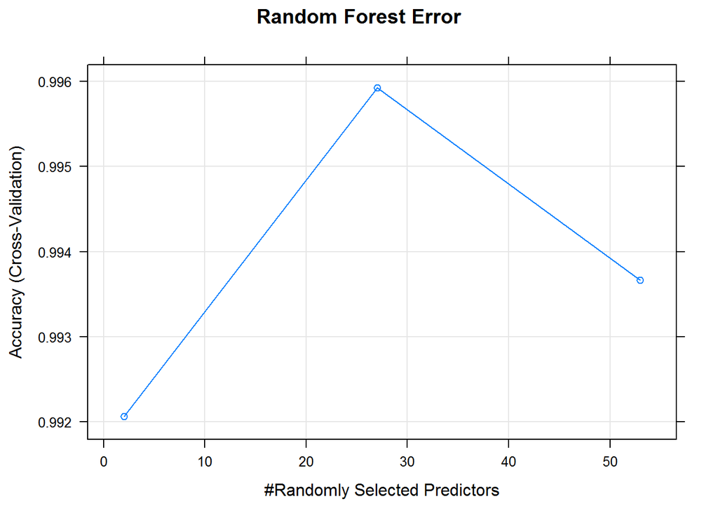

```r
plot(fit,main="Random Forest Error")
```

The model uses 53 predictors and divides the data into 5 classes with a 99% accuracy and 0.25% OOB error. That is pretty good!!! It seems that I don’t need so many predictors to do a good enough job, I will therefore look at importance based on purity of the nodes and downsize my predictors.

```r
train1.rf <- randomForest(classe ~ ., data=train1, ntree=500,keep.forest=FALSE, importance=TRUE)
x<-importance(train1.rf,type=2) #type 2=mean decarese in node impurity
y<-as.data.frame(x[order(x,decreasing=TRUE),])
y<-head(y,30) #select top 30 predictors
train_top30<-train1[,c('classe','num_window','roll_belt','yaw_belt','pitch_forearm','magnet_dumbbell_z','pitch_belt','magnet_dumbbell_y','roll_dumbbell','accel_belt_z','accel_dumbbell_y','magnet_belt_z','magnet_belt_y',
'accel_dumbbell_z','accel_forearm_x','roll_arm','total_accel_dumbbell','gyros_belt_z','magnet_arm_x',
'total_accel_belt','yaw_dumbbell','magnet_belt_x','magnet_forearm_z','accel_arm_x','accel_dumbbell_x',
'gyros_dumbbell_y','accel_forearm_z','yaw_arm','magnet_arm_y')]

Control <- trainControl(method="cv", number=3) # settings: using 3 folds
fit_top30 <- train(classe ~ ., data=train_top30, method="rf", trControl=Control) #fit the model
fit_top30
```

```
## Random Forest
##
## 13737 samples
##    28 predictor
##     5 classes: 'A', 'B', 'C', 'D', 'E'
##
## No pre-processing
## Resampling: Cross-Validated (3 fold)
## Summary of sample sizes: 9160, 9157, 9157
## Resampling results across tuning parameters:
##
##   mtry  Accuracy   Kappa      Accuracy SD  Kappa SD
##    2    0.9919920  0.9898686  0.003538057  0.004477425
##   15    0.9957049  0.9945665  0.002549701  0.003225528
##   28    0.9945406  0.9930941  0.002854551  0.003610832
##
## Accuracy was used to select the optimal model using  the largest value.
## The final value used for the model was mtry = 15.
```

```r
fit_top30$finalModel #print final model
```

```
##
## Call:
##  randomForest(x = x, y = y, mtry = param$mtry)
##                Type of random forest: classification
##                      Number of trees: 500
## No. of variables tried at each split: 15
##
##         OOB estimate of  error rate: 0.17%
## Confusion matrix:
##      A    B    C    D    E  class.error
## A 3904    1    0    0    1 0.0005120328
## B    4 2651    3    0    0 0.0026335591
## C    0    5 2391    0    0 0.0020868114
## D    0    0    4 2248    0 0.0017761989
## E    0    0    0    5 2520 0.0019801980
```

I will now test my random forest model on the 30% validation set we created earlier

```r
preds <- predict(fit_top30, train2)
confusionMatrix(train2$classe, preds)
```

```
## Confusion Matrix and Statistics
##
##           Reference
## Prediction    A    B    C    D    E
##          A 1674    0    0    0    0
##          B    4 1133    1    1    0
##          C    0    5 1021    0    0
##          D    0    0    3  960    1
##          E    0    0    0    0 1082
##
## Overall Statistics
##
##                Accuracy : 0.9975
##                  95% CI : (0.9958, 0.9986)
##     No Information Rate : 0.2851
##     P-Value [Acc > NIR] : < 2.2e-16
##
##                   Kappa : 0.9968
##  Mcnemar's Test P-Value : NA
##
## Statistics by Class:
##
##                      Class: A Class: B Class: C Class: D Class: E
## Sensitivity            0.9976   0.9956   0.9961   0.9990   0.9991
## Specificity            1.0000   0.9987   0.9990   0.9992   1.0000
## Pos Pred Value         1.0000   0.9947   0.9951   0.9959   1.0000
## Neg Pred Value         0.9991   0.9989   0.9992   0.9998   0.9998
## Prevalence             0.2851   0.1934   0.1742   0.1633   0.1840
## Detection Rate         0.2845   0.1925   0.1735   0.1631   0.1839
## Detection Prevalence   0.2845   0.1935   0.1743   0.1638   0.1839
## Balanced Accuracy      0.9988   0.9972   0.9975   0.9991   0.9995
```

```r
# re-fit model using full training set we initially downloaded with only the top 30 predictors previously selected
df_training1<-df_training1[,c('classe','num_window','roll_belt','yaw_belt','pitch_forearm','magnet_dumbbell_z','pitch_belt','magnet_dumbbell_y','roll_dumbbell','accel_belt_z','accel_dumbbell_y','magnet_belt_z','magnet_belt_y',
'accel_dumbbell_z','accel_forearm_x','roll_arm','total_accel_dumbbell','gyros_belt_z','magnet_arm_x',
'total_accel_belt','yaw_dumbbell','magnet_belt_x','magnet_forearm_z','accel_arm_x','accel_dumbbell_x',
'gyros_dumbbell_y','accel_forearm_z','yaw_arm','magnet_arm_y')]
fitControl <- trainControl(method="cv", number=3, verboseIter=F)
fit_full <- train(classe ~ ., data=df_training1, method="rf", trControl=fitControl)
fit_full$finalModel
```

```
##
## Call:
##  randomForest(x = x, y = y, mtry = param$mtry)
##                Type of random forest: classification
##                      Number of trees: 500
## No. of variables tried at each split: 15
##
##         OOB estimate of  error rate: 0.13%
## Confusion matrix:
##      A    B    C    D    E  class.error
## A 5578    1    0    0    1 0.0003584229
## B    3 3791    2    1    0 0.0015801949
## C    0    7 3415    0    0 0.0020455874
## D    0    0    6 3210    0 0.0018656716
## E    0    1    0    3 3603 0.0011089548
```

```r
fit_full
```

```
## Random Forest
##
## 19622 samples
##    28 predictor
##     5 classes: 'A', 'B', 'C', 'D', 'E'
##
## No pre-processing
## Resampling: Cross-Validated (3 fold)
## Summary of sample sizes: 13082, 13081, 13081
## Resampling results across tuning parameters:
##
##   mtry  Accuracy   Kappa      Accuracy SD   Kappa SD
##    2    0.9957190  0.9945848  0.0009176884  0.001161079
##   15    0.9979104  0.9973568  0.0012732969  0.001610830
##   28    0.9957699  0.9946489  0.0021644699  0.002738711
##
## Accuracy was used to select the optimal model using  the largest value.
## The final value used for the model was mtry = 15.
```

### Making final prediction from the observed data set

```r
final_preds <- predict(fit_full, newdata=df_testing)
final_preds <- as.character(final_preds)
final_preds
```

```
##  [1] "B" "A" "B" "A" "A" "E" "D" "B" "A" "A" "B" "C" "B" "A" "E" "E" "A"
## [18] "B" "B" "B"
```

```r
# export results
#write.csv(preds,"C:/Users/i57757/Documents/R/Practical_machine_learning_project.csv")
```